# MATH 106 - Applied Linear Statistical Models

mbanuelos22@csufresno.edu

## Last Time in Math 106 \(\ldots\)

- Scatterplots
- Residuals, Mean, and Variance Functions
- Introduction to R

## Variance Functions

Another part of the distribution of \(Y\) is described by the **variance function** ,

\[ \text{Var}(Y \;|\; X = x) \]

A frequent assumption in fitting linear regression models is that the variance function is the same for every value of x.

\[ \text{Var}(Y \;|\; X = x) = \sigma^2 \]

This is usually done for convenience but we will discuss general variance models in Ch. 7.

## Summary Graph

A *summary graph* is a scatterplot of \(Y\) versus \(X\).

**Q:** Why should you take time to explore these graphs?

- First step in exploring the relationships of variables.
- Even if not appropriate, you can estimate find the best-fit line \(\beta_0 + \beta_1 x\)
- Anscombe (1973) simulated data in `anscombe`.

## Anscombe Data

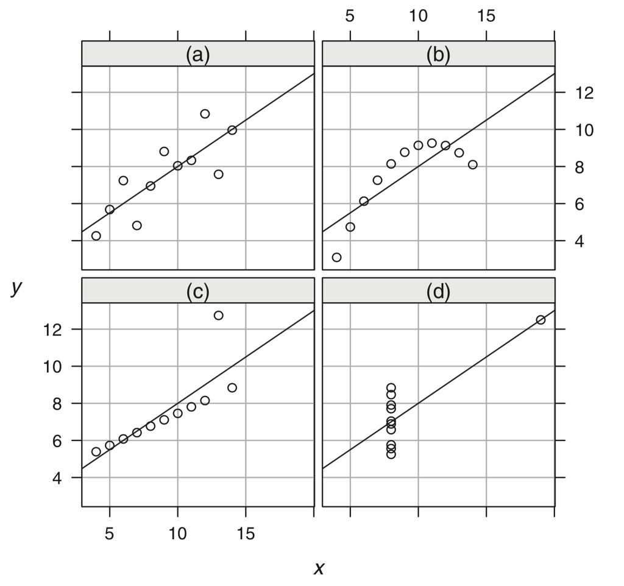

**Q:** How do we determine outliers?

## Smallmouth Bass

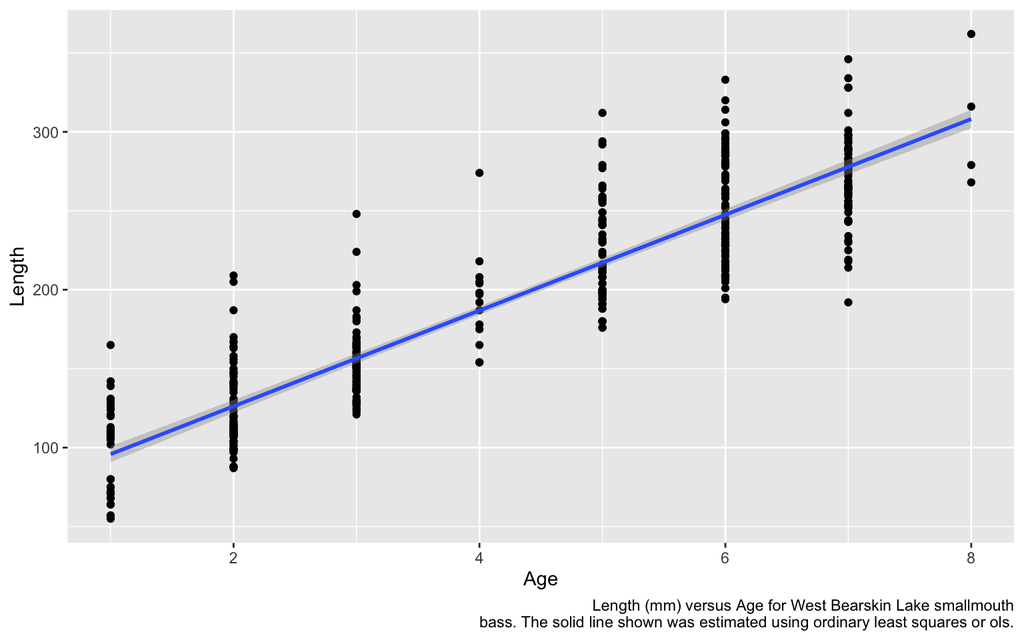

## Smallmouth Bass (cont.)

**Q:**

- What is different about this particular data?
- Can you predict the length of a smallmouth bass at age 4?

This data is from a *cross-sectional study*, as a opposed to a *longitudinal study*, where one would keep track of the age and length of the same fish over time.

## Uncorrelated Variables (Ex: Weather)

For *uncorrelated*, variables that do not show a positive or negative association, data, we will need to conduct appropriate statistical tests to check for difference.

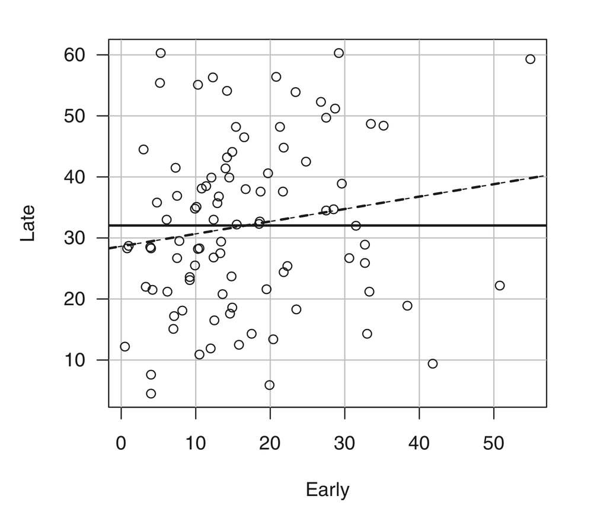

Plot of snowfall from 1900-1992 (in.). The dashed line is the ols line.

## Tools for looking at scatterplots

- **Size** - changing or resizing scales
- **Transformations** - transforming either \(X\) or \(Y\) so summary graph is more appropriate. This will usually be a log transform \(X^\lambda\).
- **Smoothers for the Mean Function** - for this class, only for visual purposes

## Scatterplot Matrices

- With one predictor, a scatterplot provides a summary of the regression relationship between \(X\) and \(Y\).
- With many predictors, we need to look at many scatterplots.
- **A scatterplot matrix** is a convenient way to organize these plots.

## Fuel Consumption

Let’s look at the `fuel2001` data in `R`,

```r
myfuel <- fuel2001
# generate a summary of all columns in data
summary(myfuel)
```

```
##     Drivers             FuelC              Income          Miles
##  Min.   :  328094   Min.   :  148769   Min.   :20993   Min.   :  1534
##  1st Qu.: 1087128   1st Qu.:  737361   1st Qu.:25323   1st Qu.: 36586
##  Median : 2718209   Median : 2048664   Median :27871   Median : 78914
##  Mean   : 3750504   Mean   : 2542786   Mean   :28404   Mean   : 77419
##  3rd Qu.: 4424256   3rd Qu.: 3039932   3rd Qu.:31208   3rd Qu.:112828
##  Max.   :21623793   Max.   :14691753   Max.   :40640   Max.   :300767
##       MPC             Pop                Tax
##  Min.   : 6556   Min.   :  381882   Min.   : 7.50
##  1st Qu.: 9391   1st Qu.: 1162624   1st Qu.:18.00
##  Median :10458   Median : 3115130   Median :20.00
##  Mean   :10448   Mean   : 4257046   Mean   :20.15
##  3rd Qu.:11311   3rd Qu.: 4845200   3rd Qu.:23.25
##  Max.   :17495   Max.   :25599275   Max.   :29.00
```

** Q: Why should `Fuel` and `Dlic` be included in this data?

## Fuel Consumption (cont.)

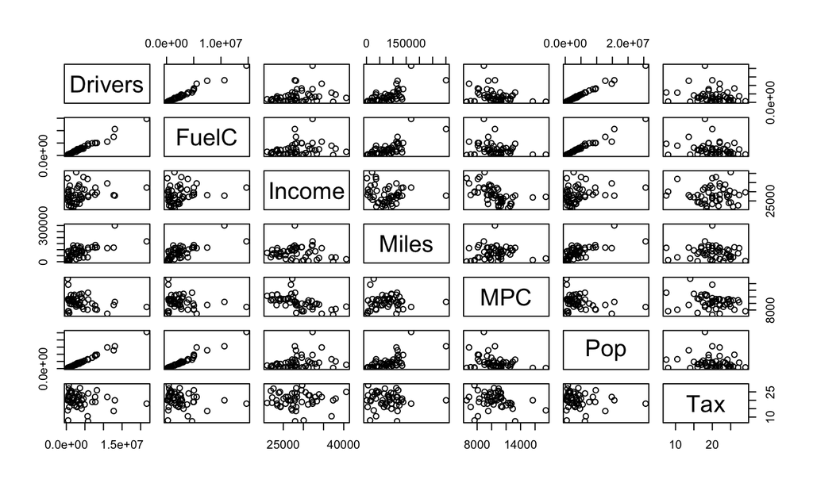

```r
# create a scatterplot matrix of fuel data
plot(myfuel)
```

## Linear Regression Preliminaries

- Notation
- Residual sum of squares (RSS)

## Notation

- The symbol \(\text{E}(u_i)\) is read as the expected value of the random variable \(u_i\).
- The phrase “expected value” is the same as the phrase “mean value.”
- Informally, the expected value of \(u_i\) is the average value of a very large sample drawn from the distribution of \(u_i\)

**Q:** What is the expected value of rolling a die?

## Expected Value

The expected value is a linear operator, which means  
\[ \begin{align*} \text{E}(a_0 +a_1u_1) &= a_0 +a_1 \text{E}(u_1)\\ \text{E}\left( a_0 +\sum a_i u_i\right) &= a_0 +\sum a_i \text{E}(u_i), \end{align*} \] where \(a_0, a_1\) are constants and \(u_i\) are random variables.

**Class Activity:** Using this information, show that the expected value of the sample mean is equal to the population mean.

## Variance

The variance is defined by the equation \[ \text{Var}(u_i) = \text{E}[u_i - \text{E}(u_i)]^2,\] the expected squared difference between an observed value for \(u_i\) and its mean value. For *uncorrelated random variables*, \[ \text{Var}\left(a_0 + \sum a_i u_i \right)= \sum a_i^2 \text{Var} (u_i). \]

**Note:** The variance of a constant is zero.